# Mini Project 1: Life Expectancy

Joe Stoica, Conor Devins

9/28/2018

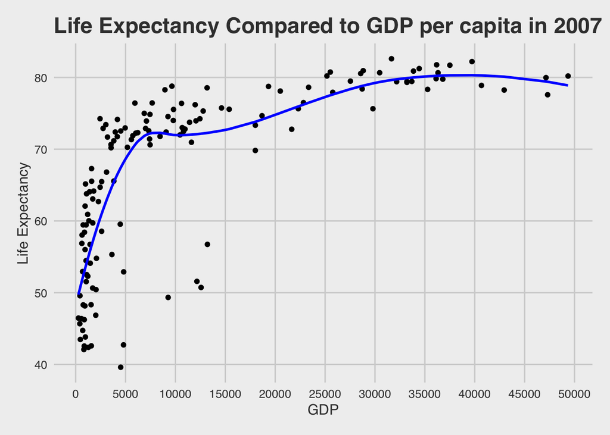

It seems that countries below about $4,000 GDP have the lowest life expectancy, but countries over $5,000 seem to all be over 70 years and continues to increase steadidly to the higher ends of GDP, besides a few outliers.

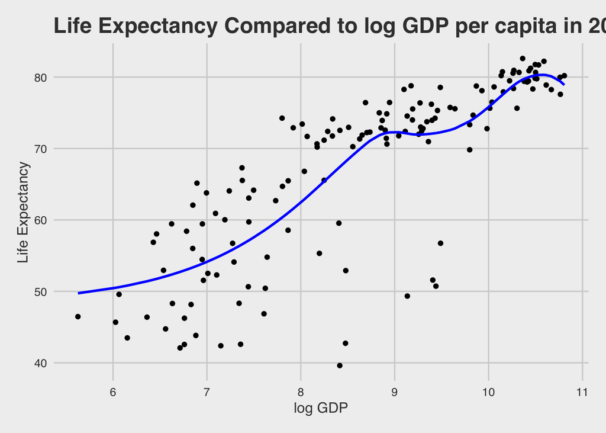

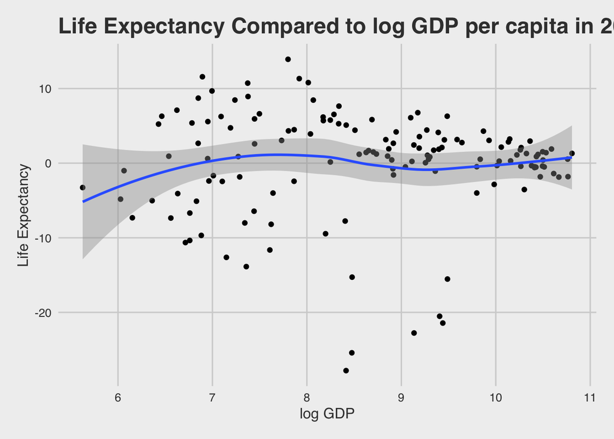

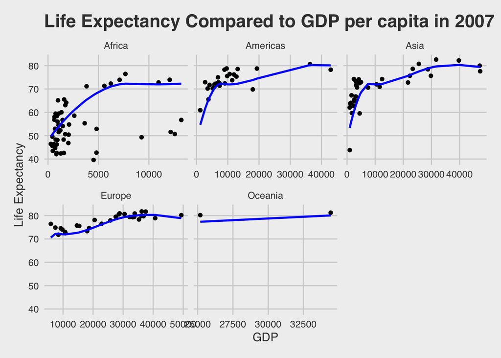

It appears that this pattern is varies across all of the continents. For Africa, the Americas, and Asia, the trend from above follows: countries with lower GDP typically has worse life expectancy, and as GDP increases, so does life expectancy. However, Europe sees high life expectancy throughout their entire range. It is difficult to make any concrete conclusions about Oceania, though, because they only have two countries. It is difficult to tell if there are any additive or multiplicative shifts due to this variance in the trends.

Life expectancy over time by continent: How has average life expectancy changed over time in each continent? Have some continents caught up (at least partially) to others? If so, is this just because of some countries in the continent, or is it more general? Have the changes been linear, or has it been faster/slower in some periods for some continents? What might explain periods of faster/slower change?

Changes in the relationship between GDP and life expectancy over time: How has the relationship between GDP and life expectancy changed in each continent? Can changes in life expectancy be entirely explained by changes in GDP per capita? Does it look like there’s a time effect on life expectancy in addition to a GDP effect? Has there been “convergence” in the sense that perhaps GDP and/or continent don’t matter as much as it used to? Are there exceptions to the general patterns?